# Part 2 - Small Problems With Linear Models

Max Chis

11/4/2021

## Introduction

The following section focuses on the development, analysis, and visualization of linear models for the starting dataset. All models are fitted in the “Part_0_Model_Generation.Rmd” file.

## Best-performing linear models.

I examined the AIC/BIC scores in order to determine which models had the best performance. My rationale was that AIC/BIC would appropriately account for the complexity of models and punish models that ran the risk of overfitting.

```r
extract_metrics <- function(mod_object, mod_name)
{
  broom::glance(mod_object) %>%
    mutate(model_name = mod_name)
}

all_fit_metrics <- purrr::map2_dfr(list(readRDS(here("models", "mod_start_additive_all.Rds")),
                                        readRDS(here("models", "mod_start_pairwise_all.Rds")),
                                        readRDS(here("models", "mod_start_2nd_poly_all.Rds")),
                                        readRDS(here("models", "mod_start_lq_ap_x09_x11.Rds")),
                                        readRDS(here("models", "mod_start_spline_x09_x11.Rds")),
                                        readRDS(here("models", "mod_start_interact_x09_x11.Rds"))),
                                   c('mod_start_additive_all',
                                     'mod_start_pairwise_all',
                                     'mod_start_2nd_poly_all',
                                     'mod_start_lq_ap_x9_x11',
                                     'mod_start_spline_x09_x11',
                                     'mod_start_interact_x9_x11'),
                                   extract_metrics)
all_fit_metrics %>% column_to_rownames(., var = "model_name") %>% select(AIC, BIC)
```

```
##                                  AIC        BIC
## mod_start_additive_all     102.07081 121.869006
## mod_start_pairwise_all     -51.99837  -3.917032
## mod_start_2nd_poly_all      98.04322 131.982981
## mod_start_lq_ap_x9_x11    -111.16404 -82.880900
## mod_start_spline_x09_x11  -137.46067 -32.813066
## mod_start_interact_x9_x11  -26.82835 -12.686781
```

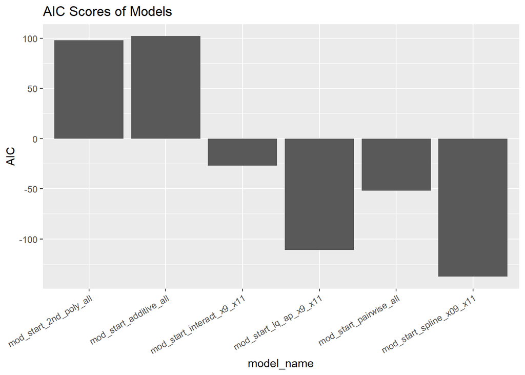

```r
all_fit_metrics %>% ggplot(aes(x=model_name, y=AIC)) + geom_col() + theme(axis.text.x = element_text(angle = 30, vjust = 1, hjust=1)) + ggtitle("AIC Scores of Models")
```

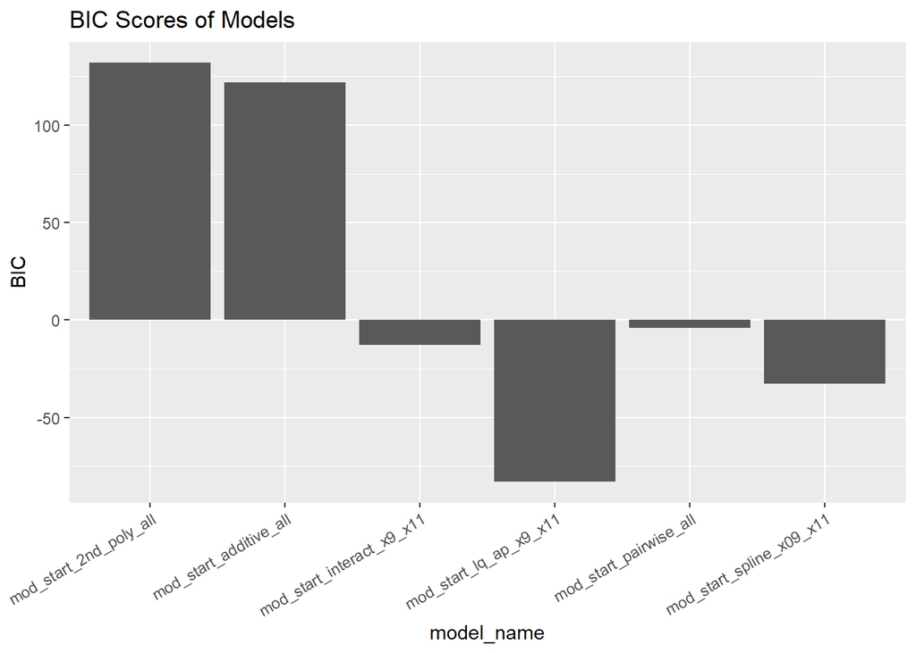

```r
all_fit_metrics %>% ggplot(aes(x=model_name, y=BIC)) + geom_col() + theme(axis.text.x = element_text(angle = 30, vjust = 1, hjust=1)) + ggtitle("BIC Scores of Models")
```

Examining solely AIC/BIC values, mod_spline_x09_x11 and mod_lq_ap_x9_x11 appear best, with the spline found to be superior in AIC, and lq_ap_x9_x11 appearing superior in BIC.

## Coefficient summaries and comparison of top 2 models.

The plotted coefficient summaries for the top 2 models are provided below.

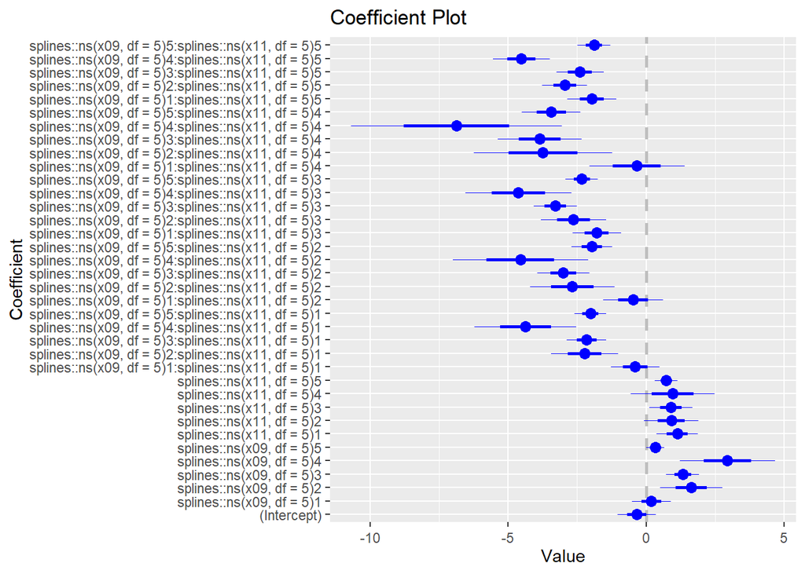

```r
readRDS(here("models", "mod_start_spline_x09_x11.Rds")) %>% coefplot::coefplot()
```

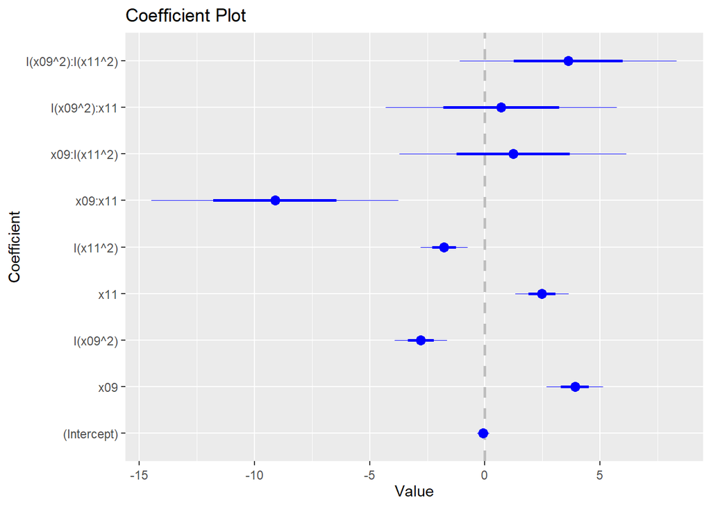

```r
readRDS(here("models", "mod_start_lq_ap_x09_x11.Rds")) %>% coefplot::coefplot()
```

Because the features are so different (spline versus quadratic), it would be inappropriate to compare their coefficient values.

## Fitting Bayesian Linear Models to top 2 models.

### Waic Comparison

I utilized stan_lm to fit the two top-performing linear models as identified in the prior section. I then compared the WAIC scores for their respective performance.

```r
mod_start_bayes_spline_x09_x11 <- readRDS(here("models", "mod_start_bayes_spline_x09_x11.Rds"))
mod_start_bayes_lq_ap_x09_x11 <- readRDS(here("models", "mod_start_bayes_lq_ap_x09_x11.Rds"))
```

Calculate WAIC values

```r
mod_start_bayes_lq_ap_x09_x11$waic <- mod_start_bayes_lq_ap_x09_x11 %>% waic()
mod_start_bayes_spline_x09_x11$waic <- mod_start_bayes_spline_x09_x11 %>% waic()
my_models <- stanreg_list(mod_start_bayes_lq_ap_x09_x11, mod_start_bayes_spline_x09_x11,
                          model_names = c("Linear and quadratic additive with all-pairwise interactions for x09 and x11.", "Spline basis x09 and x11"))
```

Compare WAIC values.

```r
loo_compare(my_models, criterion = "waic")
```

```
## Model comparison based on WAIC:
##                                                                               elpd_diff
## Spline basis x09 and x11                                                       0.0
## Linear and quadratic additive with all-pairwise interactions for x09 and x11. -9.4
##                                                                               se_diff
## Spline basis x09 and x11                                                       0.0
## Linear and quadratic additive with all-pairwise interactions for x09 and x11.  8.2
```

Utilizing WAIC metric, spline basis function performs best.

### Visualization of best model coefficient posterior distributions

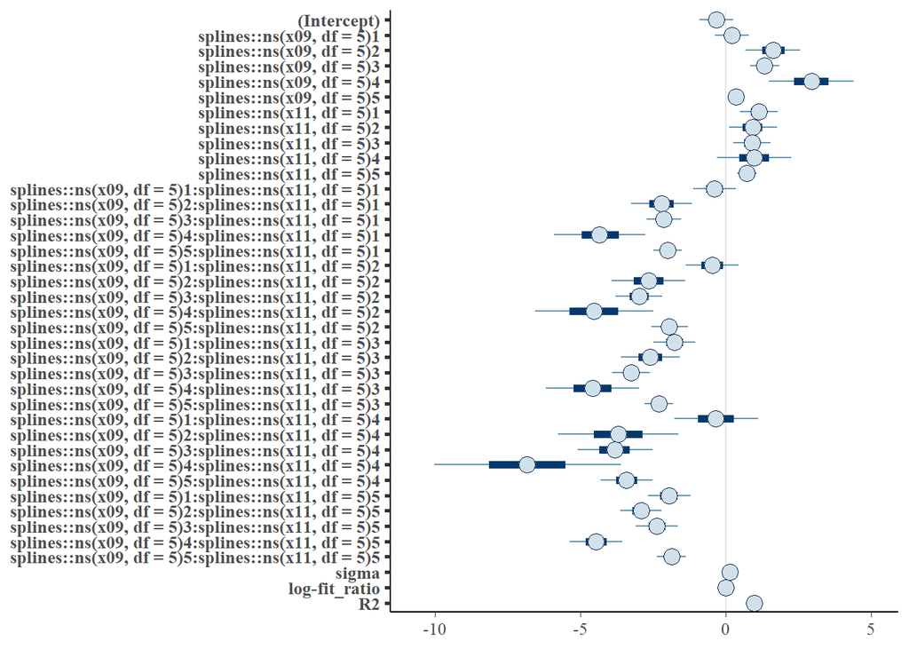

```r
mod_start_bayes_spline_x09_x11 %>% plot()
```

### Comparison of residual error posterior uncertainty with MLE

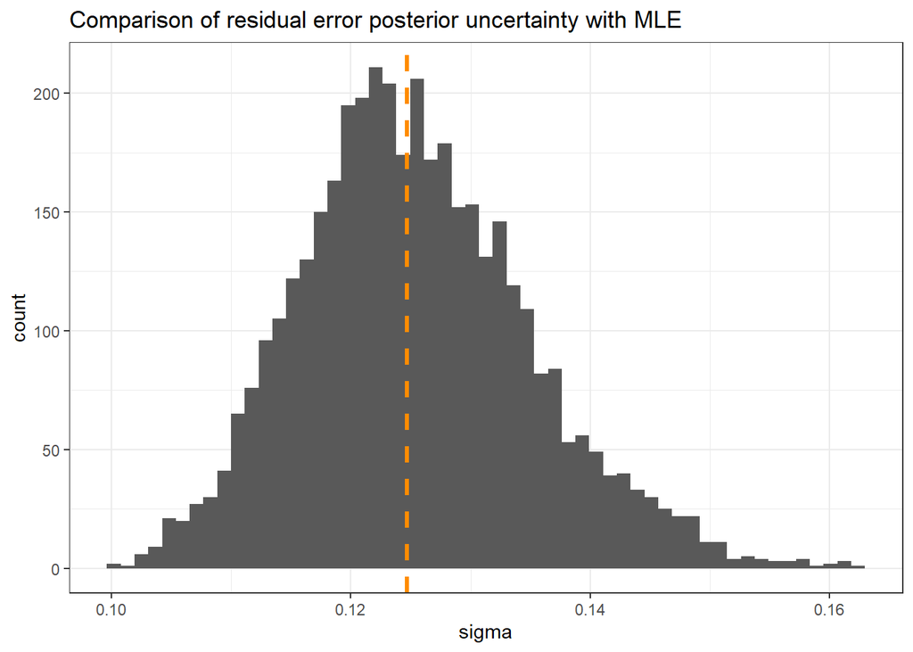

```r
as.data.frame(mod_start_bayes_spline_x09_x11) %>% tibble::as.tibble() %>%
  ggplot(mapping = aes(x = sigma)) +
  geom_histogram(bins = 55) +
  geom_vline(xintercept = stats::sigma(mod_start_bayes_spline_x09_x11),
             color = "darkorange", linetype = "dashed", size = 1.1) +
  theme_bw() + ggtitle("Comparison of residual error posterior uncertainty with MLE")
```

Viewing this graph, we see that the posterior uncertainty on Sigma is roughly normally distributed around the MLE sigma. The posterior uncertainty is also relatively small and concentrated within a small interval.

## Prediction visualization of top 2 models

The below code visualizes the predictions for the Bayesian models.

```r
#Create viz_grid
viz_grid <- expand.grid(x11 = seq(from=0, to=1, length.out=101),
                        x09 = seq(from=0, to=1, length.out=6),
                        KEEP.OUT.ATTRS = FALSE,
                        stringsAsFactors = FALSE) %>%
  as.data.frame() %>% tibble::as_tibble()
```

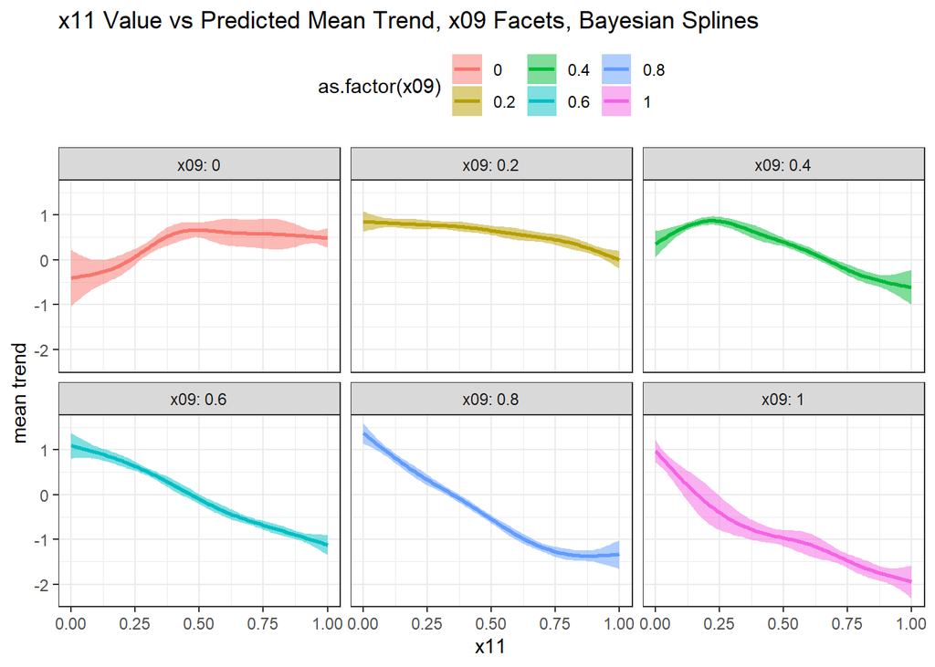

```r
posterior_linpred(mod_start_bayes_spline_x09_x11, newdata = viz_grid) %>%
  as.data.frame() %>% tibble::as_tibble() %>%
  tibble::rowid_to_column("post_id") %>%
  tidyr::gather(key = "pred_id", value = "value", -post_id) %>%
  mutate_at(c("pred_id"), as.numeric) %>%
  group_by(pred_id) %>%
  summarise(num_post = n(),
            trend_avg = mean(value),
            trend_lwr = quantile(value, 0.05),
            trend_upr = quantile(value, 0.95)) %>%
  ungroup() %>%
  left_join(viz_grid %>% tibble::rowid_to_column("pred_id"),
            by = "pred_id") %>%
  ggplot(aes(x=x11)) +   geom_ribbon(mapping = aes(
    ymin = trend_lwr,
    ymax = trend_upr,
    group = x09,
    fill=as.factor(x09)), alpha=0.5) +
  geom_line(mapping = aes(y = trend_avg, group = x09, color = as.factor(x09)), size=1.) +
  facet_wrap(~x09, labeller = "label_both") + labs(y = "mean trend") +
  theme_bw() +
  theme(legend.position = "top") + ggtitle("x11 Value vs Predicted Mean Trend, x09 Facets, Bayesian Splines")
```

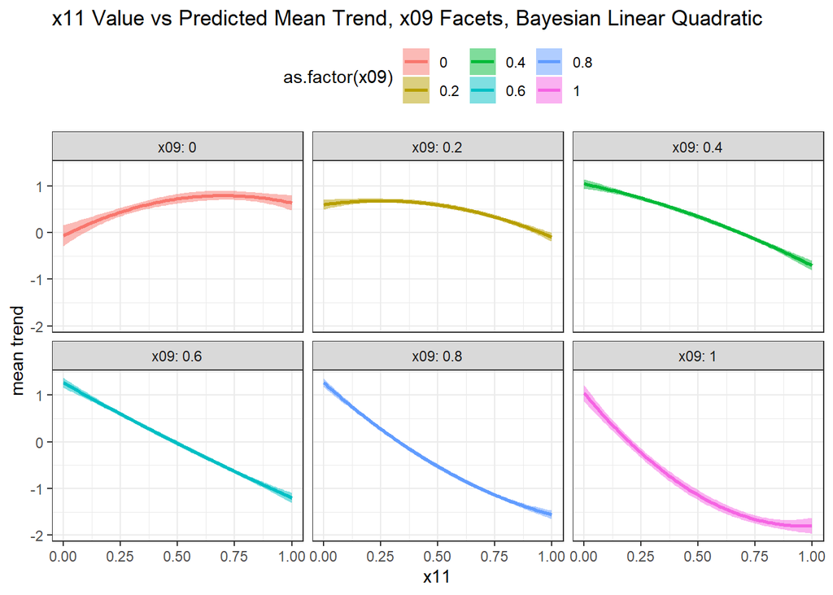

```r
posterior_linpred(mod_start_bayes_lq_ap_x09_x11, newdata = viz_grid) %>%
  as.data.frame() %>% tibble::as_tibble() %>%
  tibble::rowid_to_column("post_id") %>%
  tidyr::gather(key = "pred_id", value = "value", -post_id) %>%
  mutate_at(c("pred_id"), as.numeric) %>%
  group_by(pred_id) %>%
  summarise(num_post = n(),
            trend_avg = mean(value),
            trend_lwr = quantile(value, 0.05),
            trend_upr = quantile(value, 0.95)) %>%
  ungroup() %>%
  left_join(viz_grid %>% tibble::rowid_to_column("pred_id"),
            by = "pred_id") %>%
  ggplot(aes(x=x11)) +   geom_ribbon(mapping = aes(
    ymin = trend_lwr,
    ymax = trend_upr,
    group = x09,
    fill=as.factor(x09)), alpha=0.5) +
  geom_line(mapping = aes(y = trend_avg, group = x09, color = as.factor(x09)), size=1.) +
  facet_wrap(~x09, labeller = "label_both") + labs(y = "mean trend") +
  theme_bw() +
  theme(legend.position = "top") + ggtitle("x11 Value vs Predicted Mean Trend, x09 Facets, Bayesian Linear Quadratic")
```

### Comparing predictive trends

The broad strokes of the predictive trends are similar, but the spline model is notably more flexible than the linear-quadratic all-pairs model.

### What values minimize the mean trend?

Setting both x09 and x11 to 1 minimizes the mean trend.